# Time Perspective of Nations: `ggplot` workshop

Neil Stewart

```r
library(tidyverse)
options(width=100)
```

# Week 3 Workshop: Part 2

In Part 2 of this workshop we will draw `ggplot()`s plots of data about the relationship between the way a country searches Google for time information and their GDP

See Noguchi *et al.* (2014) for details. The timing of searches for previous and future years are characterised by focus and horizon. Focus quantifies how many searches there are for, for example, a future year compared to searches for the current year. Horizon characterises how quickly searches drop off as they are further from the current year. Noguchi *et al.* (2014) find that countries with higher GDP search more for the future and search less for the past, and think further into the future and the past when they do this.

Be sure to produce *production ready* plots, complete with *figure captions*

## Tasks for today

4. Reproduce Figure 3 from Noguchi *et al.* (2014).

This is a very tough demand! Perhaps try just to produce the top left panel first. Maybe draw each panel separately and use `gridArrange` to combine them.

If you are feeling ambitious, try reshaping the data and doing the plot in one go. The data arrive in a wide format. But plotting works better in a long format. Use `gather()` and `separate()` to reshape the data

Finally, check you can knit your Rmarkdown document to produce an HTML file documenting everything you have done

```r
(  TP <- read_csv("time_perspective_data.csv")  )
```

```
## # A tibble: 172 x 7
##    country    year    gdp future_focus future_horizon past_focus past_horizon
##    <chr>     <int>  <dbl>        <dbl>          <dbl>      <dbl>        <dbl>
##  1 Argentina  2008  8223.        0.252        0.172        0.           0.574
##  2 Argentina  2009  7667.        0.398        0.151        0.           0.511
##  3 Argentina  2010  9124.        0.607        0.0366       0.138        0.378
##  4 Argentina  2011 10942.        0.439        0.0696       0.           0.244
##  5 Hungary    2008 15365.        0.129        0.0375       0.186        0.441
##  6 Hungary    2009 12635.        0.201        0.193        0.181        0.339
##  7 Hungary    2010 12863.        0.224        0.00490      0.298        0.511
##  8 Hungary    2011 14044.        0.232        0.0457       0.188        0.327
##  9 Nigeria    2008  1375.        0.134        0.437        0.156        0.436
## 10 Nigeria    2009  1091.        0.515        0.518        0.221        0.387
## # ... with 162 more rows
```

# Reshape the data into long format

Marvel at the power of `gather()` and `separate()`

```r
TP.long <- TP %>% gather(time.attitude, time.score, c(future_focus, future_horizon, past_focus, past_horizon)) %>% separate(time.attitude, into=c("time.direction", "time.type"), sep="_")
TP.long
```

```
## # A tibble: 688 x 6
##    country    year    gdp time.direction time.type time.score
##    <chr>     <int>  <dbl> <chr>          <chr>          <dbl>
##  1 Argentina  2008  8223. future         focus          0.252
##  2 Argentina  2009  7667. future         focus          0.398
##  3 Argentina  2010  9124. future         focus          0.607
##  4 Argentina  2011 10942. future         focus          0.439
##  5 Hungary    2008 15365. future         focus          0.129
##  6 Hungary    2009 12635. future         focus          0.201
##  7 Hungary    2010 12863. future         focus          0.224
##  8 Hungary    2011 14044. future         focus          0.232
##  9 Nigeria    2008  1375. future         focus          0.134
## 10 Nigeria    2009  1091. future         focus          0.515
## # ... with 678 more rows
```

# Create factors for pretty labels on plots

```r
TP.long <- TP.long %>% mutate(time.direction=factor(time.direction, levels=c("future", "past"), labels=c("Future", "Past")))
TP.long <- TP.long %>% mutate(time.type=factor(time.type, levels=c("focus", "horizon"), labels=c("Focus", "Horizon")))
TP.long <- TP.long %>% mutate(year=as.factor(year))
```

# Recreating Figure 3

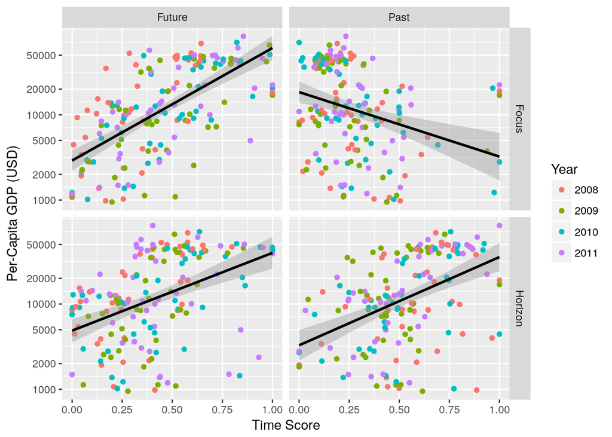

```r
ggplot(TP.long, aes(x=time.score, y=gdp)) + geom_point(aes(col=year)) + facet_grid(time.type~time.direction) + scale_y_log10(breaks=c(1000,2000,5000,10000,20000,50000)) + labs(x="Time Score", y="Per-Capita GDP (USD)", col="Year") + geom_smooth(method="lm", col="black")
```

# References

Noguchi, T. *et al.* (2014) ‘Characterizing the time-perspective of nations with search engine query data’, *PLoS ONE*, 9, p. e95209. doi: 10.1371/journal.pone.0095209.